# Titanic Binary Logistic

Fit and Inference

I Joly

16/11/2020

This exercise was adapted to discuss inference and quality of adjustments in logistic regression.

# Titanic Case Study - (source: F.E. Harrel, (2015), Regression Modeling Strategies, 2nd Ed., Springer, chap. 12)

> This case study demonstrates the development of a binary logistic regression model to describe patterns of survival in passengers on the Titanic, based on passenger age, sex, ticket class, and the number of family members accompanying each passenger.

> Titanic passenger data were gathered by many researchers. Primary references are the Encyclopedia Titanica at (www.encyclopedia-titanica.org) and Eaton andHaas.

> Titanic survival patterns have been analyzed previously but without incorporation of individual passenger ages. Thomas Cason while a University of Virginia student compiled and interpreted the data from the World Wide Web.

## Loading

```r
require(rms)
load('titanic4.RData')
```

We truncate the distribution of `sibsp` and `parch` at 3 (more than 3 spouses or more than 3 children) Missing values are noticeable for `age`.

## Descriptive Statistics

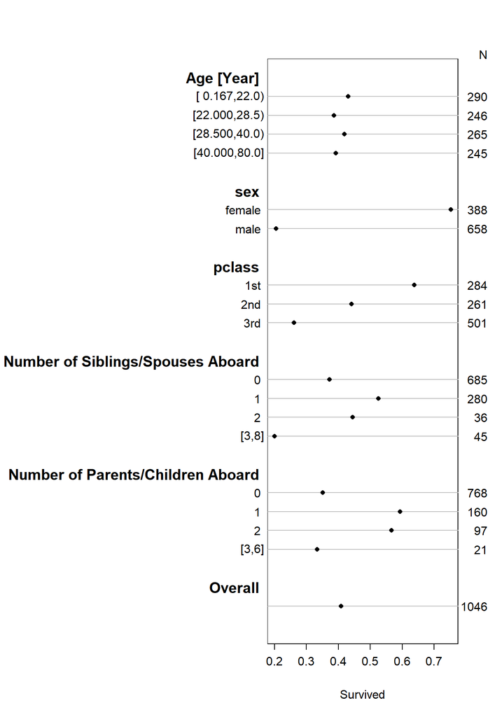

```r
dd <-  datadist(titanic4)    # describe distributions of variables to rms
options(datadist = 'dd' )
s <-  summary(survived ~ age + sex + pclass + cut2(sibsp ,0:3) + cut2(parch ,0:3), data =titanic4)
plot(s, main = ' ' , subtitles =FALSE ) # Figure 12.1
```

We can make some **assumptions** from this graph.

- Age has been broken down into classes (for ease of representation). No strong trend appears (increase or decrease in survival rate). The differences in survival rates between classes are small. The variable should not be significant.
- women survive significantly better than men.
- Passengers in first class (at the first level of the boat) may survive better than those in lower classes
- Number of children: no monotonous effect on survival rate. but different survival rates.
- Number of parents per child: no monotonous effect, but here again the rates are significantly different.

> To study show four-way empirical relationships with the fraction of surviving passengers by creating four cells for `sibsp × parch` combinations and by creating two age groups. We suppress proportions based on less than 25 passengers.

> Last 2 variables have non-monotonic effects.

## Non parametric exploration

Here we create 2 variables `sibsp` and `parch` as binary variables: parents without children and children without parents.

This is the new `tn`base.

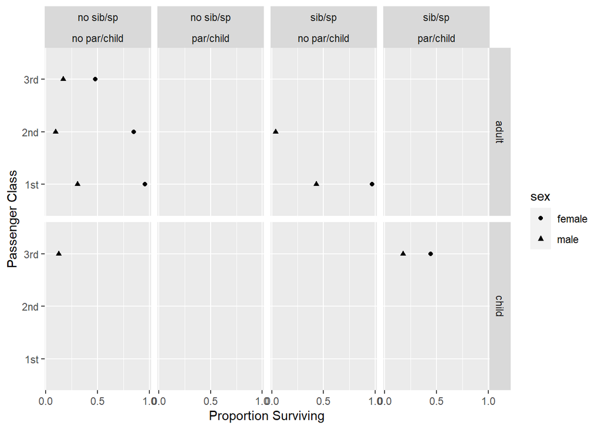

```r
tn <-  transform (titanic4 ,
  agec = ifelse(age < 21, ' child ' , ' adult ' ),
  sibsp = ifelse(sibsp == 0, ' no sib/sp ' , ' sib/sp ' ),
  parch = ifelse(parch == 0, ' no par/child ' , ' par/child ' ))
g <-  function(y) if(length (y) < 25) NA else mean(y)
s <-  with(tn , summarize (survived , llist(agec , sex , pclass , sibsp , parch ), g))
# llist , summarize in Hmisc package
# Figure 12.2:
ggplot(subset(s, agec != ' NA ' ),
aes(x=survived , y=pclass , shape =sex)) +
geom_point() + facet_grid(agec ~ sibsp * parch ) +
xlab( ' Proportion Surviving ' ) + ylab( ' Passenger Class ') +
scale_x_continuous(breaks =c(0, .5 , 1))
```

> Effects of `sibsp` and `parch` seem small on absolute risk.

[figure not shown]

```r
# Figure 12.3
b <-  scale_size_discrete(range =c(.1 , .85))
yl <-  ylab(NULL)
p1 <-  ggplot(titanic4 , aes(x=age , y=survived )) +
  histSpikeg(survived ~ age , lowess =TRUE , data =titanic4) +
  ylim (0,1) + yl
p2 <-  ggplot(titanic4 , aes(x=age , y=survived , color =sex)) +
  histSpikeg (survived ~ age + sex , lowess =TRUE ,data =titanic4) + ylim (0,1) +
  yl
p3 <-  ggplot(titanic4 , aes(x=age , y=survived , size =pclass )) +
  histSpikeg (survived ~ age + pclass , lowess =TRUE, data =titanic4) +
  b + ylim (0,1) + yl
p4 <-  ggplot(titanic4) +
  histSpikeg (survived ~ age + sex + pclass, lowess =TRUE , data =titanic4) +
  b + ylim (0,1) + yl
gridExtra::grid.arrange(p1 , p2 , p3 , p4 , ncol =2) # combine 4
```

> Nonparametric regression (loess) estimates of the relationship between age and the probability of surviving the Titanic, with tick marks depicting the age distribution. The top left panel shows unstratified estimates of the probability of survival. Other panels show nonparametric estimates by various stratifications

> Figure shows much of the story of passenger survival patterns.“Women and children first” seems to be true except for women in third class. It is interesting that there is no real cutoff for who is considered a child. For men, the younger the greater chance of surviving. The interpretation of the effects of the “number of relatives”-type variables will be more difficult, as their definitions are a function of age. Figure 12.4 shows these relationships.

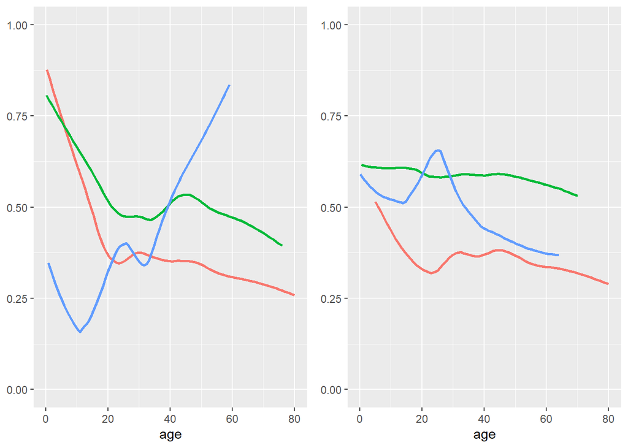

```r
top <-  theme(legend.position = ' top ' )
p1 <-  ggplot(titanic4 , aes(x=age , y=survived , color =cut2(sibsp , 0:2))) +
  stat_plsmo() + b + ylim(0,1) + yl + top +
  scale_color_discrete(name= ' siblings /spouses ' )

p2 <-  ggplot(titanic4 , aes(x=age , y=survived , color =cut2(parch , 0:2))) +
  stat_plsmo() + b + ylim(0,1) + yl + top +
  scale_color_discrete(name= ' parents/children ' )
gridExtra::grid.arrange(p1 , p2 , ncol =2)
```

## Logistic regression with `glm()`

We perform the regression `survived ~ sex+pclass + age +sibsp + parch`, on both versions of the data:

1. `tn`: where both variables `sibsp` and `parch` are binary (with or without children (or parents))
2. `titanic4` where the `sibsp` and `parch` variables are the original numeric variables: the number of children or parents

Thus, we test and compare the two models which differ only in the way `sibsp` and `parch` are integrated in the model (binary or numerical).

```r
logit_tn <- glm(data=tn, survived ~ sex+pclass +age +sibsp + parch, x = TRUE,
             family = binomial(link = "logit"))
summary(logit_tn)
```

```
##
## Call:
## glm(formula = survived ~ sex + pclass + age + sibsp + parch,
##     family = binomial(link = "logit"), data = tn, x = TRUE)
##
## Deviance Residuals:
##     Min       1Q   Median       3Q      Max
## -2.6442  -0.6860  -0.4270   0.6585   2.4002
##
## Coefficients:
##                   Estimate Std. Error z value Pr(>|z|)
## (Intercept)       3.500184   0.362950   9.644  < 2e-16 ***
## sexmale          -2.488457   0.170085 -14.631  < 2e-16 ***
## pclass2nd        -1.285287   0.227889  -5.640 1.70e-08 ***
## pclass3rd        -2.307620   0.229102 -10.072  < 2e-16 ***
## age              -0.032920   0.006542  -5.032 4.84e-07 ***
## sibsp sib/sp     -0.325122   0.181725  -1.789   0.0736 .
## parch par/child   0.355896   0.198300   1.795   0.0727 .
## ---
## Signif. codes:  0 '***' 0.001 '**' 0.01 '*' 0.05 '.' 0.1 ' ' 1
##
## (Dispersion parameter for binomial family taken to be 1)
##
##     Null deviance: 1414.62  on 1045  degrees of freedom
## Residual deviance:  977.66  on 1039  degrees of freedom
## AIC: 991.66
##
## Number of Fisher Scoring iterations: 4
```

```r
exp(coefficients(logit_tn))
```

```
##      (Intercept)          sexmale        pclass2nd        pclass3rd
##      33.12155147       0.08303798       0.27657122       0.09949773
##              age    sibsp sib/sp  parch par/child
##       0.96761575       0.72243919       1.42745910
```

```r
logit_t4 <- glm(data=titanic4, survived ~ sex+pclass +age +sibsp + parch, x = TRUE,
             family = binomial(link = "logit"))
summary(logit_t4)
```

```
##
## Call:
## glm(formula = survived ~ sex + pclass + age + sibsp + parch,
##     family = binomial(link = "logit"), data = titanic4, x = TRUE)
##
## Deviance Residuals:
##     Min       1Q   Median       3Q      Max
## -2.7018  -0.6615  -0.4199   0.6660   2.5197
##
## Coefficients:
##              Estimate Std. Error z value Pr(>|z|)
## (Intercept)  3.906791   0.361918  10.795  < 2e-16 ***
## sexmale     -2.556860   0.173270 -14.756  < 2e-16 ***
## pclass2nd   -1.366757   0.230041  -5.941 2.83e-09 ***
## pclass3rd   -2.352022   0.228803 -10.280  < 2e-16 ***
## age         -0.039489   0.006634  -5.952 2.64e-09 ***
## sibsp       -0.352915   0.105349  -3.350 0.000808 ***
## parch        0.074361   0.099907   0.744 0.456695
## ---
## Signif. codes:  0 '***' 0.001 '**' 0.01 '*' 0.05 '.' 0.1 ' ' 1
##
## (Dispersion parameter for binomial family taken to be 1)
##
##     Null deviance: 1414.62  on 1045  degrees of freedom
## Residual deviance:  970.12  on 1039  degrees of freedom
## AIC: 984.12
##
## Number of Fisher Scoring iterations: 4
```

Both models give stable results for all variables except `sibsp` and `parch`. For these two variables the variable format affects the significance and the value of the estimated coefficients.

But for the other coefficients the estimated coefficients and standard errors are similar.

We see that the AIC is lower - better - for the second model. It is therefore the best of the two models in the sense of the AIC. But the AIC gap is not very high. We can reflect on the interest of this version of the model compared to the previous one, which is simpler to interpret. The transformation into binary variables reduces the information available but facilitates interpretation. In particular, the introduction of the two variables `sibsp` and `parch` in a numerical way is not consistent with the observation of a non-monotonic effect on the survival rate.

```r
LR_tn<-with(logit_tn,deviance/null.deviance) # -2 cancels out
LRI_tn<-1-LR_tn    ;   LRI_tn
```

```
## [1] 0.3088899
```

```r
LR_t4<-with(logit_t4,deviance/null.deviance) # -2 cancels out
LRI_t4<-1-LR_t4    ;   LRI_t4
```

```
## [1] 0.3142194
```

Looking at deviances and McFadden’s $R^2$ (or LRI), we have the same interpretation: the second model is better: McFadden’s $R^2$ is higher 0.3142194.

We note in particular the level of $-2 \times log(L_0)$ of the *null* model common to both models. Indeed, for these two models it is the version where only the intercept is present. This level of deviance is used as a reference in the calculation of goodness of fit (including the LRI, in the denominator).